# statar

Matthieu Gomez

2015-06-06

# Summary functions

## summarize

`sum_up` prints detailed summary statistics (corresponds to Stata summarize)

```r
N <- 100
df <- data_frame(
  id = 1:N,
  v1 = sample(5, N, TRUE),
  v2 = sample(1e6, N, TRUE)
)
sum_up(df)
df %>% sum_up(starts_with("v"), d = TRUE)
df %>% group_by(v1) %>%  sum_up()
```

`tab` prints distinct rows with their count. Compared to the dplyr function `count`, this command just adds Frequency and Cumulative frequency.

```r
N <- 1e2 ; K = 10
df <- data_frame(
  id = sample(5, N, TRUE),
  v1 = sample(5, N, TRUE)
)
tab(df, id, v1)
tab(df, id, v1, na.rm = TRUE)
df %>% group_by(id) %>% tab(v1)
```

## Join

- The option `check` checks there are no duplicates in the master or using data.tables (as in Stata).

- The option `update` allows to update missing values of the master dataset by the value in the using dataset

## Visual exploration

`stat_binmean()` is a layer for ggplot2. It allows to compute the mean of y over the mean of x within bins of x, similarly to Stata command binscatter,

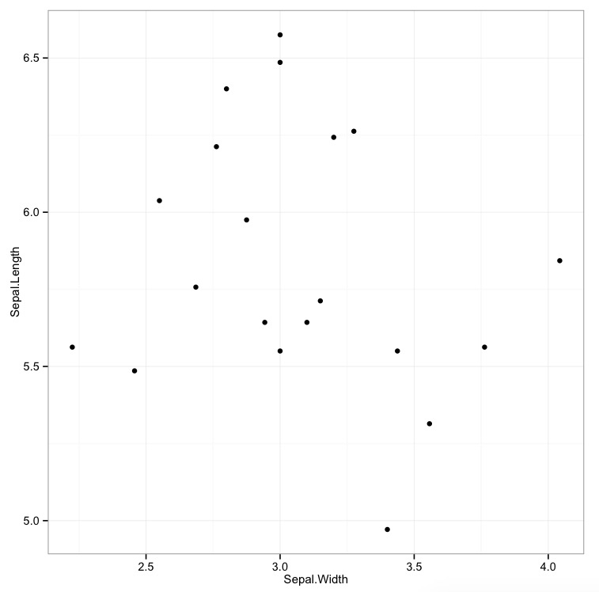

```r
ggplot(iris, aes(x = Sepal.Width , y = Sepal.Length)) + stat_binmean()
```

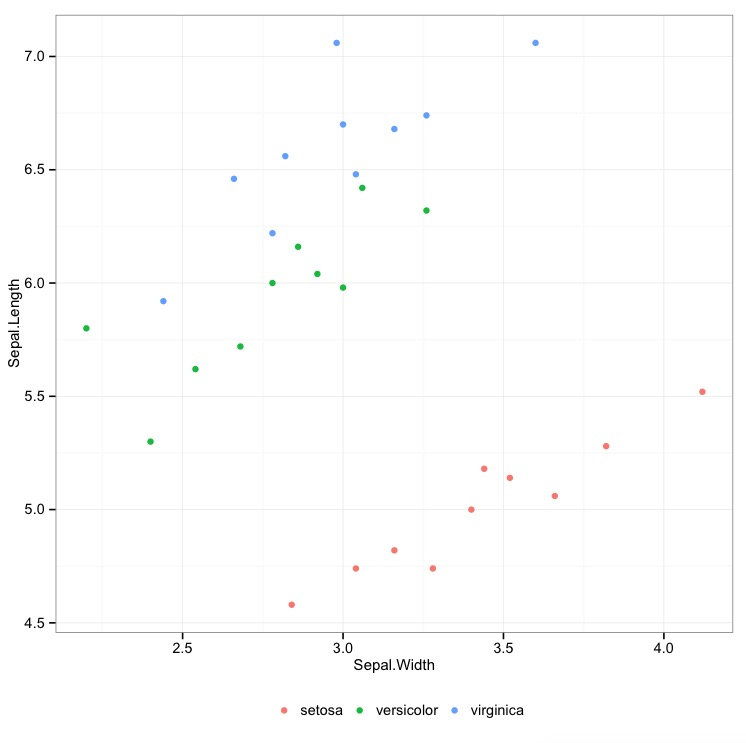

```r
ggplot(iris, aes(x = Sepal.Width , y = Sepal.Length, color = Species)) + stat_binmean(n=10)
```

Since `stat_binmean` is just a layer for ggplo2, you can surimpose any model fit

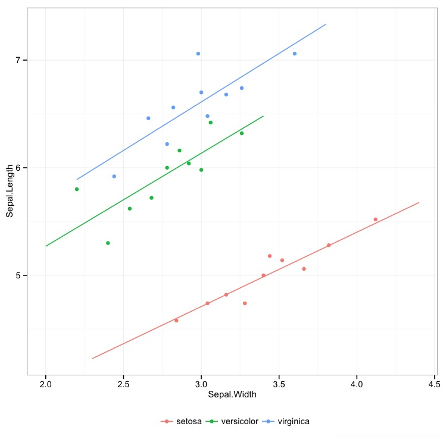

```r
ggplot(iris, aes(x = Sepal.Width , y = Sepal.Length, color = Species)) + stat_binmean(n=10) + stat_smooth(method = "lm", se = FALSE)
```